# Elction & Social Media:

### An analysis of how Donald Trump interacts with his base through his Truth Social account

## Introduction

Donald Trump is a political phenomenon—after two impeachments, refusal to accept a fair election, becoming a convicted felon, and two assassination attempts, he has refused to call his presidential career and has again ended up in the White House. This analysis aims to explore how Trump uses his Truth Social profile to interact with his voter base. By examining his posts, we can gain insights into his communication strategies, the topics he emphasizes, and how he engages with his supporters.

Understanding Trump's social media interactions is crucial because it sheds light on the methods he uses to maintain and mobilize his voter base. Social media has become a powerful tool in modern politics, and analyzing Trump's use of Truth Social can provide valuable insights into the broader landscape of political communication.

The data for this analysis was scraped from Trump's Truth Social account by a Kaggle user and posted and downloaded from Kaggle. Previous analyses have focused on Trump's use of Twitter, but this study will provide a fresh perspective by examining his interactions on Truth Social, a platform he has adopted more recently. That being said, this analysis will refer to Truth Social posts (Thruths, as they are officially called) as tweets for convenience.

By comparing this analysis with previous studies on Trump's social media usage, we can identify patterns and changes in his communication style and strategies. This will help us understand how he adapts to different platforms and continues to influence his supporters.

It should be noted that this analysis does not in any way seek to express a political standpoint. The images are meant to be funny, not offensive.

```python
import numpy as np
import pandas as pd
import matplotlib.pyplot as plt
import seaborn as sns
# for background images
import matplotlib.image as mpimg
# for regular expressions
import re

import warnings
warnings.filterwarnings('ignore')

import matplotlib

# updating the default settings of pyplot so that graphs look prettier.
plt.rcParams.update({
    'font.family': 'serif',
    'axes.titleweight': 'bold',
    'axes.labelweight': 'bold',
    'axes.grid': True,
    'grid.color': '#E0E0E0',
})
```

## Data Cleaning & Preprocessing

```python
tweets = pd.read_json('data/trump_tweets.json')
tweets.head(3)
```

|  | account_name | account_handle | verified_badge | post_date | profile_link | avatar_url | post_url | status_text | video_urls | replies | shares | likes | image_urls |
| --- | --- | --- | --- | --- | --- | --- | --- | --- | --- | --- | --- | --- | --- |
| 0 | Donald J. Trump | Donald J. Trump | True | 2024-10-04 21:48:00 | https://truthsocial.com/@realDonaldTrump | https://static-assets-1.truthsocial.com/tmtg:p... | https://truthsocial.com/@realDonaldTrump/posts... |  | [{'url': 'https://1a-1791.com/video/fw/s8/2/f/... | 640 | 1,48k | 3,28k | None |
| 1 | Donald J. Trump | Donald J. Trump | True | 2024-10-04 06:37:00 | https://truthsocial.com/@realDonaldTrump | https://static-assets-1.truthsocial.com/tmtg:p... | https://truthsocial.com/@realDonaldTrump/posts... | KAMALA HARRIS: “AND FINALLY PUTTING AN END TO ... | [{'url': 'https://1a-1791.com/video/fw/s8/2/D/... | 775 | 3,96k | 10,9k | None |
| 2 | Donald J. Trump | Donald J. Trump | True | 2024-10-04 20:56:00 | https://truthsocial.com/@realDonaldTrump | https://static-assets-1.truthsocial.com/tmtg:p... | https://truthsocial.com/@realDonaldTrump/posts... |  | None | 830 | 2,07k | 6,26k | [https://static-assets-1.truthsocial.com/tmtg:... |

```python
def convert_value(value):
    if 'k' in value:
        value = value.replace(',', '.').replace('k', '')
        return int(float(value) * 1000)
    else:
        return int(value)
```

```python
tweets_df = tweets[['post_date', 'status_text', 'video_urls', 'replies', 'shares', 'likes', 'image_urls']]

tweets_df['shares'] = tweets_df['shares'].apply(convert_value)
tweets_df['likes'] = tweets_df['likes'].apply(convert_value)
tweets_df['replies'] = tweets_df['replies'].apply(convert_value)
tweets_df['date'] = pd.to_datetime(tweets_df['post_date']).dt.date

tweets_df.head(3)
```

|  | post_date | status_text | video_urls | replies | shares | likes | image_urls | date |
| --- | --- | --- | --- | --- | --- | --- | --- | --- |
| 0 | 2024-10-04 21:48:00 |  | [{'url': 'https://1a-1791.com/video/fw/s8/2/f/... | 640 | 1480 | 3280 | None | 2024-10-04 |
| 1 | 2024-10-04 06:37:00 | KAMALA HARRIS: “AND FINALLY PUTTING AN END TO ... | [{'url': 'https://1a-1791.com/video/fw/s8/2/D/... | 775 | 3960 | 10900 | None | 2024-10-04 |
| 2 | 2024-10-04 20:56:00 |  | None | 830 | 2070 | 6260 | [https://static-assets-1.truthsocial.com/tmtg:... | 2024-10-04 |

## Exploring Activity by Days

```python
def get_mean(value):
    return int(value.mean())

daily_tweets_df = tweets_df.groupby('date').agg(
    count = ('post_date', 'count'),
    total_likes = ('likes', 'sum'),
    total_shares = ('shares', 'sum'),
    total_replies = ('replies', 'sum'),
    mean_likes = ('likes', get_mean),
    mean_shares = ('shares', get_mean),
    mean_replies = ('replies', get_mean)
)
```

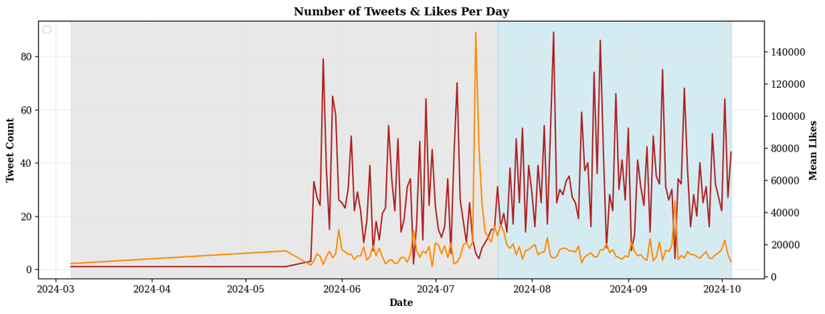

```python
fig, ax1 = plt.subplots(figsize=(14, 5))

ax1.plot(daily_tweets_df['count'], color='firebrick')
ax1.set_xlabel('Date')
ax1.set_ylabel('Tweet Count')

ax2 = ax1.twinx()

ax2.plot(daily_tweets_df['mean_likes'], color='darkorange')
ax2.set_ylabel('Mean Likes')

ax1.axvspan(daily_tweets_df.index[0], pd.Timestamp('2024-07-21'), color='lightgrey', alpha=0.5, label='Biden Campaign')
ax1.axvspan(pd.Timestamp('2024-07-21'), daily_tweets_df.index[-1], color='lightblue', alpha=0.5, label='Harris Campaign')

plt.xticks(rotation=80, ha='center')

plt.grid()

plt.title('Number of Tweets & Likes Per Day', weight='bold')
plt.xlabel('Date', weight='bold')

plt.show()
```

```python
top3 = tweets_df.sort_values(by='likes', ascending=False).head(3).reset_index()
top3
```

[output not shown]

```python
print(top3.loc[0, 'status_text'])
```

```
I want to thank The United States Secret Service, and all of Law Enforcement, for their rapid response on the shooting that just took place in Butler, Pennsylvania. Most importantly, I want to extend my condolences to the family of the person at the Rally who was killed, and also to the family of an…
```

## Exploring Activity By Times of the Day

Now let's explore the activity patterns of Trump and his followers within a day.

First, we'll create pivot table to get all the date - hour pairs (ex. 2024-03-06 - 17)

```python
tweets_df['hour'] = pd.to_datetime(tweets_df['post_date']).dt.hour
```

```python
tweets_day_hour = tweets_df.pivot_table(index='date', columns='hour', aggfunc='size', fill_value=0)
tweets_day_hour.head(3)
```

| hour date | 0 | 1 | 2 | 3 | 4 | 5 | 6 | 7 | 8 | 9 | ... | 14 | 15 | 16 | 17 | 18 | 19 | 20 | 21 | 22 | 23 |
| --- | --- | --- | --- | --- | --- | --- | --- | --- | --- | --- | --- | --- | --- | --- | --- | --- | --- | --- | --- | --- | --- |
| 2024-03-06 | 0 | 0 | 0 | 0 | 0 | 0 | 0 | 0 | 0 | 0 | ... | 0 | 0 | 0 | 0 | 0 | 0 | 0 | 0 | 0 | 1 |
| 2024-05-14 | 0 | 1 | 0 | 0 | 0 | 0 | 0 | 0 | 0 | 0 | ... | 0 | 0 | 0 | 0 | 0 | 0 | 0 | 0 | 0 | 0 |
| 2024-05-22 | 1 | 0 | 0 | 0 | 1 | 1 | 0 | 0 | 0 | 0 | ... | 0 | 0 | 0 | 0 | 0 | 0 | 0 | 0 | 0 | 0 |

```python
mean_count = pd.DataFrame(tweets_day_hour.mean(), columns=['mean tweets count'])
mean_count.head(3)
```

| hour | mean tweets count |
| --- | --- |
| 0 | 1.724638 |
| 1 | 1.876812 |
| 2 | 1.456522 |

For making the data more informative later in the plots, two functions are defined:

- military_to_ampm: converts hours to ampm format
- time_of_day: returns the time of the day (morning, afternoon, evening, nihght) that a given hour belongs to

```python
def military_to_ampm(hour):
    if hour == 0:
        return '12 AM'
    elif hour < 12:
        return f'{hour} AM'
    elif hour == 12:
        return '12 PM'
    else:
        return f'{hour - 12} PM'

def time_of_day(hour):
    if hour >= 5 and hour < 12:
        return 'Morning'
    elif hour >= 12 and hour < 17:
        return 'Afternoon'
    elif hour >= 17 and hour < 21:
        return 'Evening'
    else:
        return 'Night'
```

Now, the rows in `mean_count` are reordered, so that they start at 5AM (beginning of the morning). Then, the functions defined above are applied to create the `ampm` and `time_of_day` columns.

```python
# reordering the hours so get morning - afternoons - evening - night
first_five = mean_count.head(5)
remaining = mean_count.tail(len(mean_count) - 5)
mean_count = pd.concat([remaining, first_five]).reset_index()

# adding the ampm column using the military_to_ampm function
mean_count['ampm'] = mean_count['hour'].apply(military_to_ampm)

# adding the time_of_day column using the time_of_dat function:
mean_count['time_of_day'] = mean_count['hour'].apply(time_of_day)

tweets_by_time_of_day = mean_count.groupby('time_of_day').agg(num_tweets = ('mean tweets count', 'mean'))
```

```python
def reorder(df):
    first_five = df.head(5)
    remaining = df.tail(df.shape[0] - 5)
    return pd.concat([remaining, first_five]).reset_index()
```

Now time to visualize!

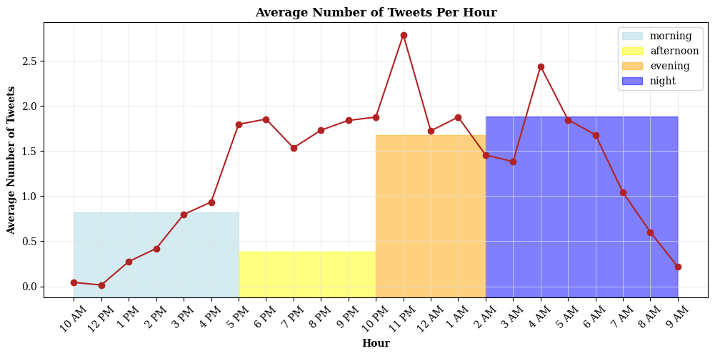

```python
# reordering the hours so get morning - afternoons - evening - night
mean_count = reorder(mean_count)

mean_count['ampm'] = mean_count['hour'].apply(military_to_ampm)

# plotting mean hourly tweets
fix, ax = plt.subplots(figsize=(12, 5))

plt.plot(mean_count['mean tweets count'], '-o', color='firebrick')

max_y = ax.get_ylim()[1]

ax.axvspan(0, 6, 0, tweets_by_time_of_day.loc['Morning', 'num_tweets']/max_y, color='lightblue', alpha=0.5, label='morning')
ax.axvspan(6, 11, 0, tweets_by_time_of_day.loc['Afternoon', 'num_tweets']/max_y, color='yellow', alpha=0.5, label='afternoon')
ax.axvspan(11, 15, 0, tweets_by_time_of_day.loc['Evening', 'num_tweets']/max_y, color='orange', alpha=0.5, label='evening')
ax.axvspan(15, 22, 0, tweets_by_time_of_day.loc['Night', 'num_tweets']/max_y, color='blue', alpha=0.5, label='night')

ax.set_title('Average Number of Tweets Per Hour')
ax.set_xlabel('Hour')
ax.set_ylabel('Average Number of Tweets')

ax.set_xticks(ticks=mean_count.index, labels=mean_count['ampm'], rotation=45)

ax.legend()
plt.show()
```

```python
likes_shares_by_hour = tweets_df.groupby('hour').agg(
    mean_likes = ('likes', 'mean'),
    mean_shares = ('shares', 'mean')
).reset_index()
```

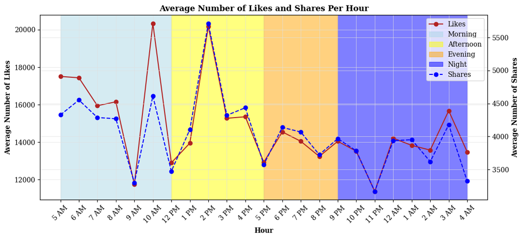

```python
# Reordering the hours to get morning, afternoon, evening, night
likes_shares_by_hour = reorder(likes_shares_by_hour)
likes_shares_by_hour['ampm'] = likes_shares_by_hour['hour'].apply(military_to_ampm)

# Plotting mean hourly tweets
fig, ax1 = plt.subplots(figsize=(12, 5))

# Plot mean likes
ax1.plot(likes_shares_by_hour['mean_likes'], '-o', color='firebrick', label='Likes')
ax1.set_xlabel('Hour')
ax1.set_ylabel('Average Number of Likes')
ax1.tick_params(axis='y')

# Create a second y-axis for mean shares
ax2 = ax1.twinx()
ax2.plot(likes_shares_by_hour['mean_shares'], '--o', color='blue', label='Shares')
ax2.set_ylabel('Average Number of Shares')
ax2.tick_params(axis='y')

# Highlighting different parts of the day
max_y = max(ax1.get_ylim()[1], ax2.get_ylim()[1])

ax1.axvspan(0, 6, color='lightblue', alpha=0.5, label='Morning')
ax1.axvspan(6, 11, color='yellow', alpha=0.5, label='Afternoon')
ax1.axvspan(11, 15, color='orange', alpha=0.5, label='Evening')
ax1.axvspan(15, 22, color='blue', alpha=0.5, label='Night')

# Combining legends from both axes
lines_1, labels_1 = ax1.get_legend_handles_labels()
lines_2, labels_2 = ax2.get_legend_handles_labels()
ax1.legend(lines_1 + lines_2, labels_1 + labels_2, loc='upper right')

ax1.set_title('Average Number of Likes and Shares Per Hour')
ax1.set_xticks(ticks=likes_shares_by_hour.index, labels=likes_shares_by_hour['ampm'], rotation=45)

plt.show()
```

## Kinds of Media in the Tweets

There are 3 kinds of media that a tweet can contain: text, images, and videos. Let's explore how Trump uses and combines them.

```python
def get_media_types(tweet):
    media_types = []

    if tweet['status_text'] != '':
        media_types.append('Text')
    if tweet['image_urls']:
        media_types.append('Image')
    if tweet['video_urls']:
        media_types.append('Video')
    if not media_types:
        return 'Empty'

    return ', '.join(media_types)
```

Now, the function is applied to the rows of the data frame, and the output is used to create a new column containing the types of media used. If a tweet is classified as 'Empty', there was likely a scraping error in the dataset, so we'll get rid of the empty tweets.

```python
media_types = tweets_df.apply(get_media_types, axis=1)
tweet_types_df = tweets_df.copy()
tweets_df['media types'] = media_types

# removing empty tweets
tweet_types_df = tweets_df[tweets_df['media types'] != 'Empty']
tweet_types_df.head(3)
```

|  | post_date | status_text | video_urls | replies | shares | likes | image_urls | date | hour | media types |
| --- | --- | --- | --- | --- | --- | --- | --- | --- | --- | --- |
| 0 | 2024-10-04 21:48:00 |  | [{'url': 'https://1a-1791.com/video/fw/s8/2/f/... | 640 | 1480 | 3280 | None | 2024-10-04 | 21 | Video |
| 1 | 2024-10-04 06:37:00 | KAMALA HARRIS: “AND FINALLY PUTTING AN END TO ... | [{'url': 'https://1a-1791.com/video/fw/s8/2/D/... | 775 | 3960 | 10900 | None | 2024-10-04 | 6 | Text, Video |
| 2 | 2024-10-04 20:56:00 |  | None | 830 | 2070 | 6260 | [https://static-assets-1.truthsocial.com/tmtg:... | 2024-10-04 | 20 | Image |

Now let's group by the `media types` column to get the nuber of tweets that belong to each category anf then visualize the data in a pie chart.

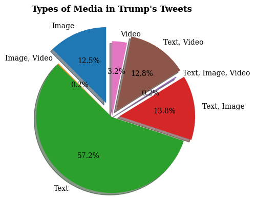

```python
by_type_df = tweet_types_df.groupby('media types').agg(count = ('likes', 'count'))

plt.pie(by_type_df['count'], labels=by_type_df.index, autopct='%1.1f%%', shadow=True, startangle=90, explode=[0.2, 0, 0, 0.1, 0, 0.1, 0])
plt.title('Types of Media in Trump\'s Tweets', pad=15)

plt.show()
```

## Exploring Allies/ Opponents

Let's start by creating a function that takes a names list that contains strings for different ways to refer to a given poerson (ex. Kamala Harris -> ['Kamala', 'Harris']) and data frame and returns a list with:

- the name of the person
- the total number of tweets that mention the person
- the mean number of likes that tweets mentioning this name have

The output represents a row in a data frame.

```python
def get_row(names, df):
    pattern = '|'.join(names)

    mask = df['status_text'].str.contains(pattern, case=False, regex=True)
    contains_name = df[mask]

    means = [np.round(contains_name[col].mean(), 2) for col in ['likes', 'shares']]

    return np.array([' '.join(names[:2]), mask.sum()] + means)
```

Now we have to come up with a list of people to search for in the tweets. Luckily, it can be accurately assumed that some of the most mentioned names are:

| **Allies** | **Opponents** |
| --- | --- |
| 1. Matt Gaetz | 1. Joe Biden |
| 2. Elon Musk | 2. Kamala Harris |
| 3. Robert F. Kennedy Jr. | 3. Barack Obama |
| 4. Todd Blanche | 4. Hillary Clinton |
| 5. Doug Collins | 5. Liz Cheney |
| 6. Doug Burgum | 6. Jack Smith |
| 7. Mike Waltz | 7. Mark Milley |
| 8. Marco Rubio | 8. Jim Himes |
| 9. Mike Johnson | 9. Nancy Pelosi |
| 10. Tulsi Gabbard | 10. Adam Kinzinger |
| 11. Jim Jordan | 11. Jake Sullivan |

Let's define lists to store all the ways Trump can refer to the people listed above.

```python
allies = [
    ['Matt', 'Gaetz'], ['Robert', 'Kennedy', 'RFK'], ['Todd', 'Blanche'],
    ['Doug', 'Collins'], ['Doug', 'Burgum'], ['Mike', 'Waltz'], ['Elon', 'Musk'],
    ['Marco', 'Rubio'], ['Mike', 'Johnson'], ['Tulsi', 'Gabbard'], ['Jim', 'Jordan']
]

opponents = [
    ['Joe', 'Biden'], ['Kamala', 'Harris'], ['Barack', 'Obama'],
    ['Hillary', 'Clinton'], ['Liz', 'Cheney'], ['Jack', 'Smith'], ['Adam', 'Kinzinger'],
    ['Mark', 'Milley'], ['Jim', 'Himes'], ['Jake', 'Sullivan'], ['Nancy', 'Pelosi']
]
```

```python
text_tweets_df = tweets_df[tweets_df['status_text'] != '']

opponents_df = pd.DataFrame([get_row(names, text_tweets_df) for names in opponents], columns=['name', 'count', 'mean_likes', 'mean_shares'])
opponents_df = opponents_df.astype({'count': 'int', 'mean_likes': 'float', 'mean_shares': 'float'})
opponents_df['relationship'] = 'Opponent'

allies_df = pd.DataFrame([get_row(names, text_tweets_df) for names in allies], columns=['name', 'count', 'mean_likes', 'mean_shares'])
allies_df = allies_df.astype({'count': 'int', 'mean_likes': 'float', 'mean_shares': 'float'})
allies_df['relationship'] = 'Ally'

people_mentioned_df = pd.concat([opponents_df, allies_df], axis=0).sort_values('count', ascending=False)
people_mentioned_df.head()
```

|  | name | count | mean_likes | mean_shares | relationship |
| --- | --- | --- | --- | --- | --- |
| 1 | Kamala Harris | 678 | 15286.99 | 4624.18 | Opponent |
| 0 | Joe Biden | 531 | 16921.80 | 4695.91 | Opponent |
| 7 | Mark Milley | 97 | 14029.48 | 3946.70 | Opponent |
| 5 | Jack Smith | 57 | 13886.67 | 4057.53 | Opponent |
| 4 | Liz Cheney | 42 | 20164.29 | 5495.69 | Opponent |

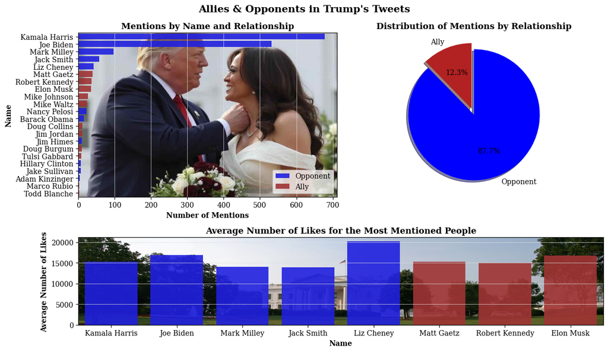

```python
# Create figure and gridspec
fig = plt.figure(figsize=(12, 7))
fig.suptitle('Allies & Opponents in Trump\'s Tweets', weight='bold', fontsize=14)

gs = plt.GridSpec(3, 2, height_ratios=[7, 1, 1])

# Background image
bg_image1 = mpimg.imread('images/bg1.jpg')
bg_image2 = mpimg.imread('images/bg2.jpg')

# First subplot: Bar plot
ax1 = plt.subplot(gs[0, 0])
sns.barplot(data=people_mentioned_df, x='count', y='name', hue='relationship', palette=['blue', 'firebrick'], ax=ax1, alpha=0.9)
ax1.imshow(bg_image1, aspect='auto', extent=ax1.get_xlim() + ax1.get_ylim(), zorder=0)
plt.legend(loc='lower right')
plt.title('Mentions by Name and Relationship')
plt.xlabel('Number of Mentions')
plt.ylabel('Name')

# Second subplot: Pie chart
counts_df = people_mentioned_df.groupby('relationship').agg(num_mentions=('count', 'sum'))
ax2 = plt.subplot(gs[0, 1])
plt.pie(counts_df['num_mentions'], labels=counts_df.index, colors=['firebrick', 'blue'], autopct='%1.1f%%', shadow=True, startangle=90, explode=[0.1, 0])
plt.title('Distribution of Mentions by Relationship')

# Third subplot: Bar plot for mean likes and shares

ax3 = plt.subplot(gs[1:, :])
most_mentioned = people_mentioned_df.head(8)

sns.barplot(data=most_mentioned, x='name', y='mean_likes', hue='relationship', palette=['blue', 'firebrick'], ax=ax3, alpha=0.9, legend=False)
plt.imshow(bg_image2, aspect='auto', extent=ax3.get_xlim() + ax3.get_ylim(), zorder=0)
plt.title('Average Number of Likes for the Most Mentioned People')
plt.xlabel('Name')
plt.ylabel('Average Number of Likes')

plt.tight_layout()
plt.show()
```

**Analysis:**

It can be seen that Trump much prefers talking about his political opponents. The most mentioned people in his tweets are Kamala Harris and Joe Biden, highlighting his focus on the top of the opposing ticket. A striking 87.7% of the mentions are political enemies, underscoring Trump's strategy of targeting adversaries to rally his base. Matt Gaetz stands out as the most mentioned ally out of the ones that were picked for the analysis, indicating a selective approach in highlighting supportive figures. This pattern suggests a deliberate use of social media to emphasize conflict and opposition, which may be a tactic to energize his supporters. This can be further backed by the fact that Trump's base reacts especially stromgly to tweets concerning Liz Chaney: an opponent that used to be a supporter.

It shoudl also be noted that the top 3 most mentioned allies are all nominated for very powerful givernment positions now. Good for them. On a serious note, this demonstrates the importance Trump places on loyalty as he is building his administration.

## Trump Likes Nicknames...

Demeaning nicknames have been an unseparble part of Trump's politocal rhetoric. Let's explore which ones he used to target his main opponents: Kamala Harris, Joe Biden, and Tim Walz.

To exctract nicknames, we are going to create a function that takes a string and a name and, using a regular expression, checks for a capitalized word that comes before the specified name (Trump always capitalizes his nicknames, ex: Sleepy Joe). The function also excludes common words that may start a sentence (When, If, Since, As, etc).

```python
def extract_nicknames(text, name):
    pattern = re.compile(rf'\b([A-Z][a-z]*)\s+({name})\b')
    matches = pattern.findall(text)

    if not matches:
        return np.nan
    elif matches[0][0] in ['When', 'Under', 'If', 'Will', 'What', 'Unlike', 'Real', 'Since', 'As', 'But']:
        return np.nan
    else:
        return ' '.join(matches[0])
```

The method used is not perfect, so we will manually extract the nicknames from the output of the function.

Kamala Harris nicknames:

```python
harris_names = pd.DataFrame(tweets_df['status_text'].apply(lambda tweet: extract_nicknames(tweet, 'Kamala')).dropna()).groupby('status_text').agg(
    num_mentions = ('status_text', 'count')
)
harris_names = harris_names.sort_values(by='num_mentions', ascending=False).head().reset_index()
harris_names
```

|  | status_text | num_mentions |
| --- | --- | --- |
| 0 | Comrade Kamala | 93 |
| 1 | Crazy Kamala | 26 |
| 2 | Czar Kamala | 4 |
| 3 | Radical Kamala | 2 |
| 4 | About Kamala | 1 |

```python
harris_names = harris_names.drop(4).reset_index()
harris_names['Target'] = 'Kamala Harris'
```

```python
walz_names = pd.DataFrame(tweets_df['status_text'].apply(lambda tweet: extract_nicknames(tweet, 'Tim')).dropna()).groupby('status_text').agg(
    num_mentions = ('status_text', 'count')
)
walz_names = walz_names.sort_values(by='num_mentions', ascending=False).head().reset_index()
walz_names
```

|  | status_text | num_mentions |
| --- | --- | --- |
| 0 | Tampon Tim | 12 |
| 1 | Congressman Tim | 2 |
| 2 | Senator Tim | 2 |
| 3 | Senators Tim | 1 |
| 4 | Weirdo Tim | 1 |

Tim Walz nicknames:

```python
walz_names = walz_names.drop([1, 2, 3, 4]).reset_index()
walz_names['Target'] = 'Tim Walz'
```

```python
biden_names = pd.DataFrame(tweets_df['status_text'].apply(lambda tweet: extract_nicknames(tweet, 'Joe')).dropna()).groupby('status_text').agg(
    num_mentions = ('status_text', 'count')
)
biden_names = biden_names.sort_values(by='num_mentions', ascending=False).head().reset_index()
biden_names
```

|  | status_text | num_mentions |
| --- | --- | --- |
| 0 | Crooked Joe | 171 |
| 1 | Sleepy Joe | 9 |
| 2 | Hold Joe | 3 |
| 3 | President Joe | 2 |
| 4 | The Joe | 2 |

Joe Biden nicknames:

```python
biden_names = biden_names.drop([2, 3, 4])
biden_names['Target'] = 'Joe Biden'
```

```python
nicknames_df = pd.concat([harris_names, walz_names, biden_names]).drop(columns='index')
nicknames_df
```

|  | status_text | num_mentions | Target |
| --- | --- | --- | --- |
| 0 | Comrade Kamala | 93 | Kamala Harris |
| 1 | Crazy Kamala | 26 | Kamala Harris |
| 2 | Czar Kamala | 4 | Kamala Harris |
| 3 | Radical Kamala | 2 | Kamala Harris |
| 0 | Tampon Tim | 12 | Tim Walz |
| 0 | Crooked Joe | 171 | Joe Biden |
| 1 | Sleepy Joe | 9 | Joe Biden |

#### Visualizing Nickname Usage

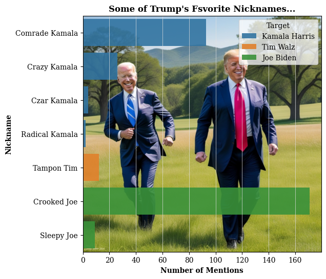

```python
plt.figure(figsize=(6, 6))
bg_image3 = mpimg.imread('images/bg4.jpg')

sns.barplot(data=nicknames_df, y='status_text', x='num_mentions', hue='Target', alpha=0.9)
plt.imshow(bg_image3, aspect='auto', extent=plt.xlim() + plt.ylim(), zorder=0)

plt.title('Some of Trump\'s Fsvorite Nicknames...')
plt.xlabel('Number of Mentions')
plt.ylabel('Nickname')

plt.show()
```

## What Issues Does Trump Emphasize?

The 5 key issues that Trump ran on were:

- The economy
- Illigal immigration
- Restoring the worldwide respect for America, ending the war in Ukraine (foreign affairs)
- Wokeism & transgender issues
- Abortion

While abortion was not among his main talking points, he had to address it on many occasions, and he has been vocal about his views on it, so it will be added to the list.

Let's create a function `categorize_tweet` that takes a tweet and returns a list with the isses from above that it concerns.

```python
def categorize_tweet(tweet):
    # store words related to each issue in list
    economy_words = ['inflation', 'tax cuts', 'jobs', 'unemployment', 'GDP', 'recession', 'trade', 'tariffs', 'market', 'taxes']
    immigration_words = ['deportation', 'border', 'wall', 'immigrants', 'asylum', 'ICE', 'border security', 'illegal', 'refugees', 'Mexico']
    transgender_words = ['LGBTQ', 'bathroom bill', 'trans', 'gender', 'non-binary', 'woke', 'radical left']
    abortion_words = ['pro-life', 'pro-choice', 'abortion', 'roe v. wade', 'planned parenthood', 'reproductive']
    foreign_affairs_words = ['ukraine', 'gaza', 'russia', 'china', 'war', 'foreign policy', 'international', 'diplomacy', 'sanctions', 'nato', 'ww3', 'afghanistan']

    tweet_lower = tweet.lower()
    issues = []

    # check if there is at least one word in the tweet that is also in one of the lists above
    if any(word in tweet_lower for word in economy_words):
        issues.append('Economy')
    if any(word in tweet_lower for word in immigration_words):
        issues.append('Immigration')
    if any(word in tweet_lower for word in transgender_words):
        issues.append('Transgender Issues')
    if any(word in tweet_lower for word in abortion_words):
        issues.append('Abortion')
    if any(word in tweet_lower for word in foreign_affairs_words):
        issues.append('Foreign Affairs')
    if not issues:
        return 'Other'

    return issues
```

Now let's apply the function to the `status_text` column to create a new column called `issue` that stores lists of issues that the given tweet talks about. Then, `pd.DataFrame.explode()` can be used to make sure that `issue` contains singe values.

```python
# applying the function to the 'status_text' column to get the 'issue' column
text_tweets_df['issue'] = text_tweets_df['status_text'].apply(categorize_tweet)
# using pd.DataFrame.explode() so that the values in the issue column are not lists
issues_df = text_tweets_df.explode('issue')
# removing tweets that do not concern any of the issues
issues_df = issues_df[issues_df['issue'] != 'Other']
issues_df.sample(3)
```

|  | post_date | status_text | video_urls | replies | shares | likes | image_urls | date | hour | media types | issue |
| --- | --- | --- | --- | --- | --- | --- | --- | --- | --- | --- | --- |
| 1350 | 2024-08-25 13:30:00 | Who is negotiating for us in the Middle East? ... | None | 1530 | 6310 | 21300 | None | 2024-08-25 | 13 | Text | Foreign Affairs |
| 214 | 2024-09-29 03:08:00 | Kamala’s Illegal Migrants. It’s the biggest cr... | None | 2000 | 5700 | 19600 | None | 2024-09-29 | 3 | Text | Immigration |
| 4053 | 2024-05-26 23:21:00 | Congressman Nick LaLota is doing an incredible... | None | 43 | 1150 | 4610 | None | 2024-05-26 | 23 | Text | Economy |

Grouping by the issue to get the number of tweets and mean number of likes per issue:

```python
issues_data = issues_df.groupby('issue').agg(
    num_tweets = ('likes', 'count'),
    mean_likes = ('likes', 'mean')
).reset_index()

issues_data
```

|  | issue | num_tweets | mean_likes |
| --- | --- | --- | --- |
| 0 | Abortion | 12 | 18323.333333 |
| 1 | Economy | 302 | 13412.582781 |
| 2 | Foreign Affairs | 316 | 17053.851266 |
| 3 | Immigration | 490 | 13719.181633 |
| 4 | Transgender Issues | 127 | 16921.023622 |

Visualizing the data:

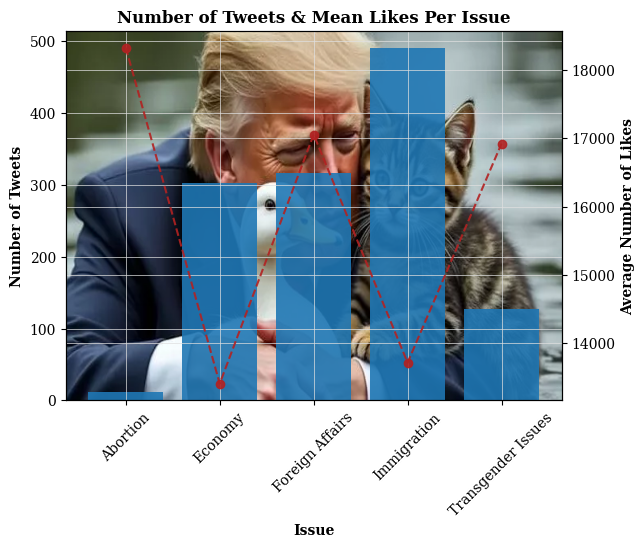

```python
_, ax1 = plt.subplots()
plt.xticks(rotation=45)

bg_image4 = mpimg.imread('images/bg3.webp')

# plotting number of tweets per issue
ax1.bar(issues_data['issue'], issues_data['num_tweets'], alpha=0.9)
ax1.set_title('Number of Tweets & Mean Likes Per Issue')
ax1.imshow(bg_image4, aspect='auto', extent=ax1.get_xlim() + ax1.get_ylim(), zorder=0)
ax1.set_ylabel('Number of Tweets')
ax1.set_xlabel('Issue')

# plotting mean likes
ax2 = ax1.twinx()
ax2.plot(issues_data['mean_likes'], '--o', color='firebrick', alpha=0.9)
ax2.set_ylabel('Average Number of Likes')

plt.show()
```